# QC for Mouse Array

Aisha Dahir

# Introduction

This is an R Markdown document for the Quality Control (QC) of Mammalian array data for Dementia Mouse samples.

### Study Information

**Study:** Dementia Mouse

**Description:** 2 plates of mouse samples (whole and sorted)

**Arrays ran by:** Isabel Castanho, The University of Exeter Medical School

**Array used:** Mammalian Array

**QC done by:**Aisha Dahir, The University of Exeter Medical School

**Date of QC:** 04 March 2020

**Sample tissue:** Cortex Entorhinalis, Hippocampus, Sorted nuclei (neuN_pos, neuN_neg and total)

# 1 Loading data

As the array is not 450K nor EPIC, reading in the files may differ as well as the following QC methods. Probes and samples will be excluded at the end of the sample.

# 2 Intensity check

The intensity check is the biggest indicator of sample quality. The median methylated signal intensity and unmethylated signal intensity for each sample is calculcated.

A histogram and scatter plot of the resulting data are plotted to visualise the data quality. Samples are coloured by methylation plate or institute, to make sure there are no batch effects.

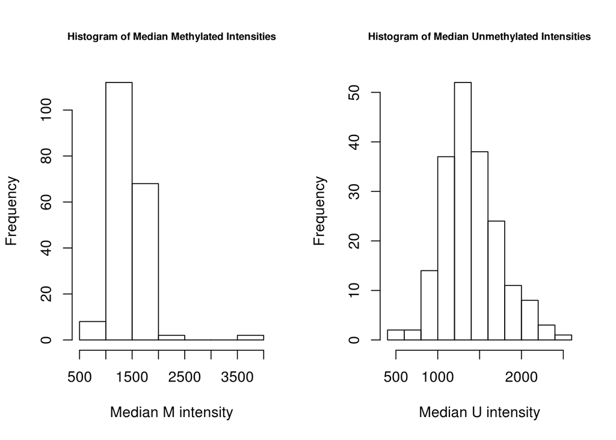

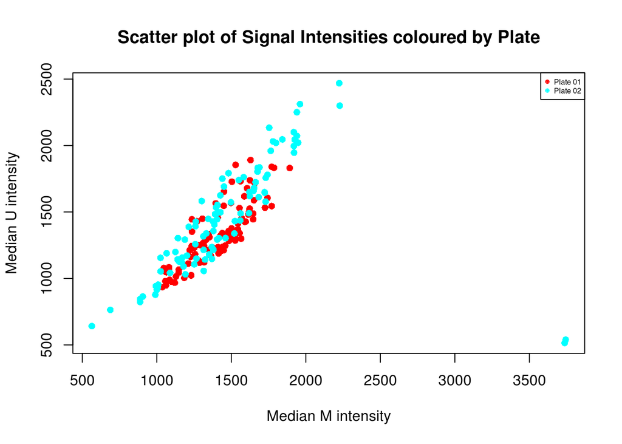

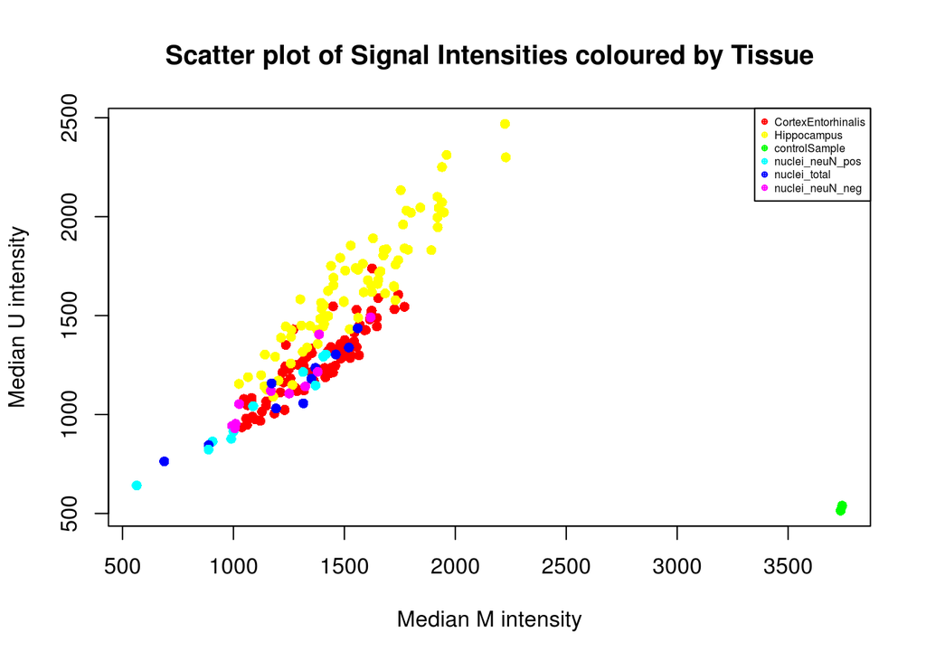

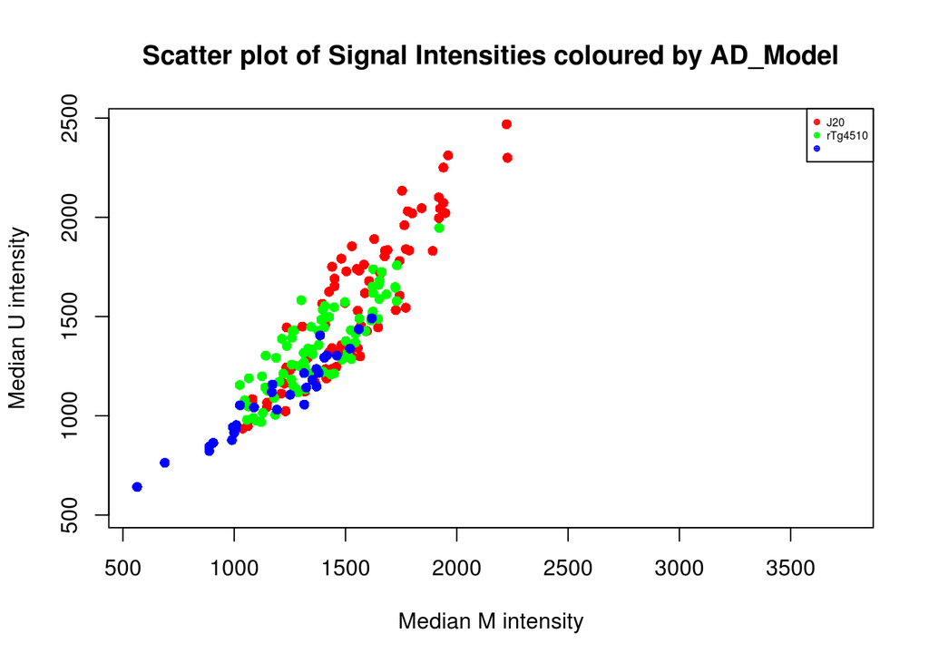

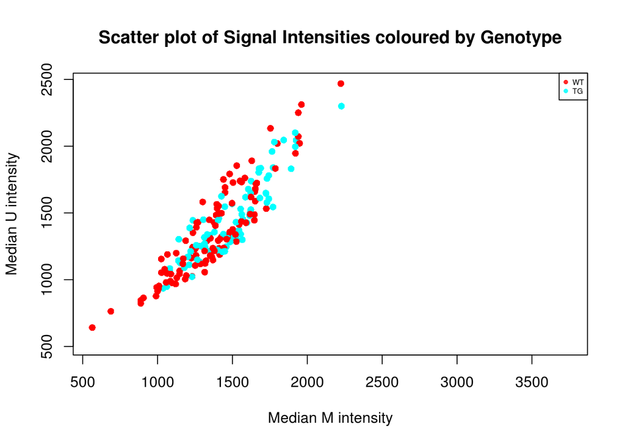

## Plate 1

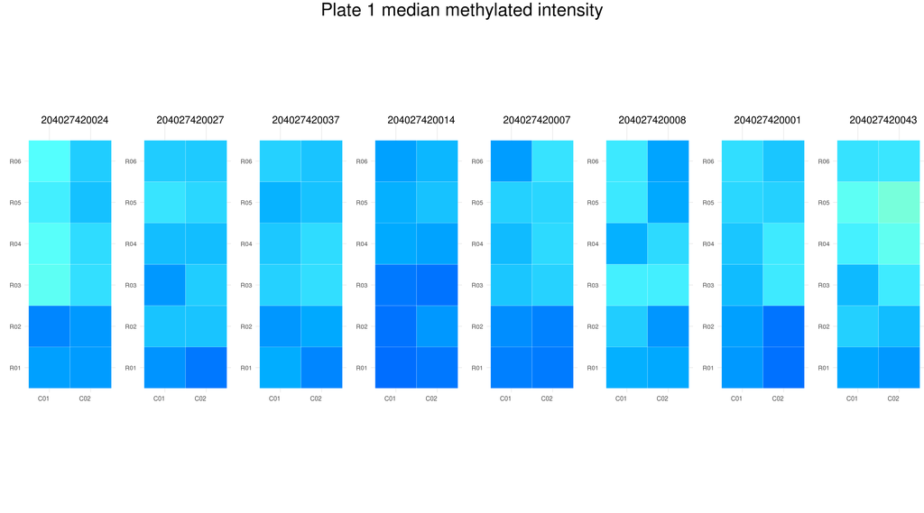

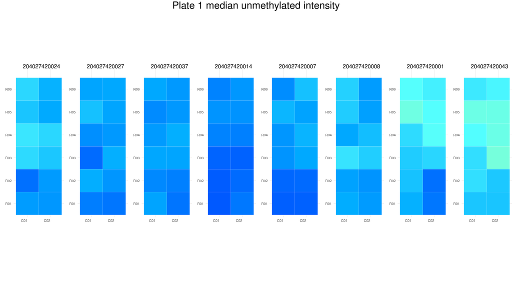

[figure not shown]

## Plate 2

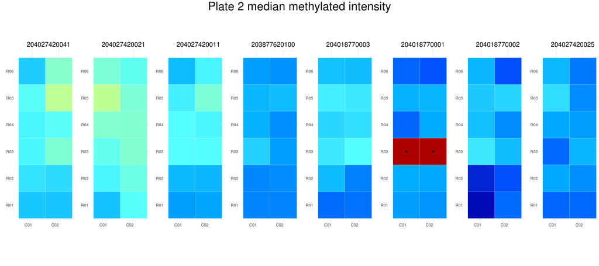

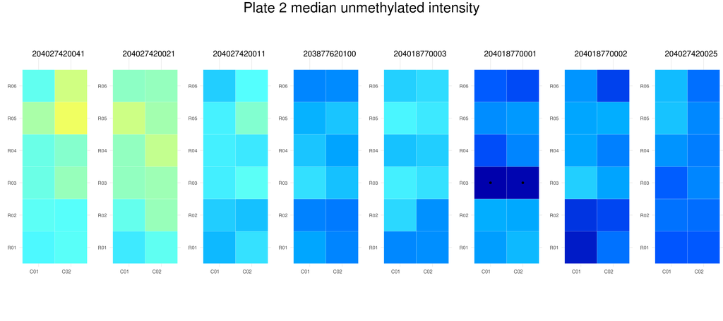

[figure not shown]

## Removing Low Intensity Samples

Although signal intensity is the largest predictor of sample quality, the threshold at which to exclude samples can vary from experiment to experiment - for example, signal intensities can vary slightly depending on tissue type or DNA extraction method. Samples which clearly deviate from the main cluster on the signal intensity plots should be removed.

```r
M.median<-M.median[!sample_sheet$Control]
U.median<-U.median[!sample_sheet$Control]
SamplesFail<-SamplesFail[!sample_sheet$Control]
QCmetrics<-QCmetrics[!sample_sheet$Control,]
RGset2<-RGset[,!sample_sheet$Control]
sample_sheet<-sample_sheet[!sample_sheet$Control,]
```

```r
lowintensitysamples<-which(M.median < 800 | U.median < 800)
```

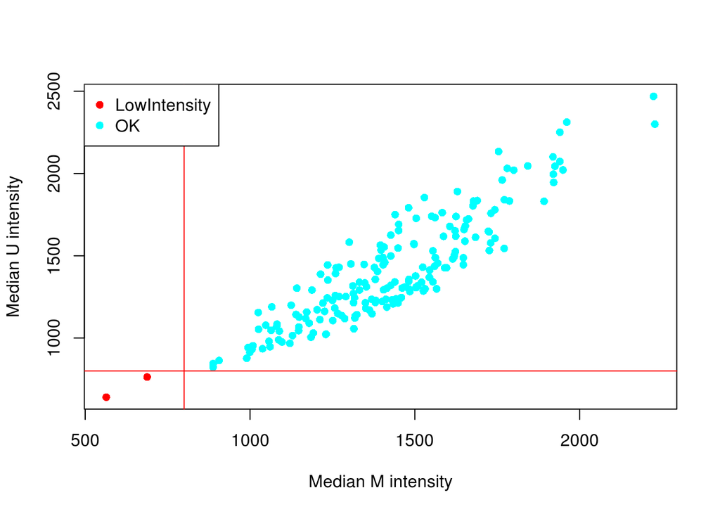

```r
print(Stepsummary)
```

```
##                  Step1
## Failed This Step     2
## Total Failed         2
```

# 3 Bisulphite Conversion

A bisulphite conversion statistic for each sample was calculated, and a histogram of the results plotted. Samples with a conversion < 80% fail the QC.

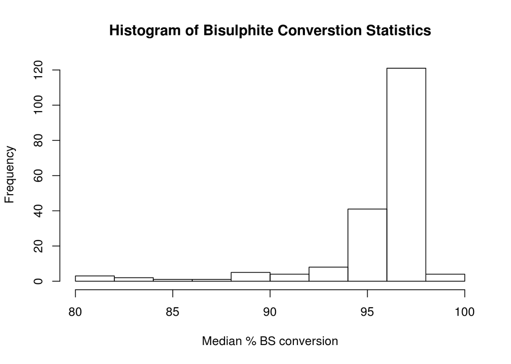

Samples with a conversion < 80% fail the QC, so with this threshold 0 samples fail the QC, and will be removed at a later stage.

```r
print(Stepsummary)
```

```
##                  Step1 Step2
## Failed This Step     2     0
## Total Failed         2     2
```

# 4 Sex Check

We can check the sex of the samples by comparing the sex probes intensities.

```
## [1] "Top correlated principal components with sex: 2 , 1"
## [1] "Top PC has r > 0.9 with sex so good enough to confirm reported sexes"
```

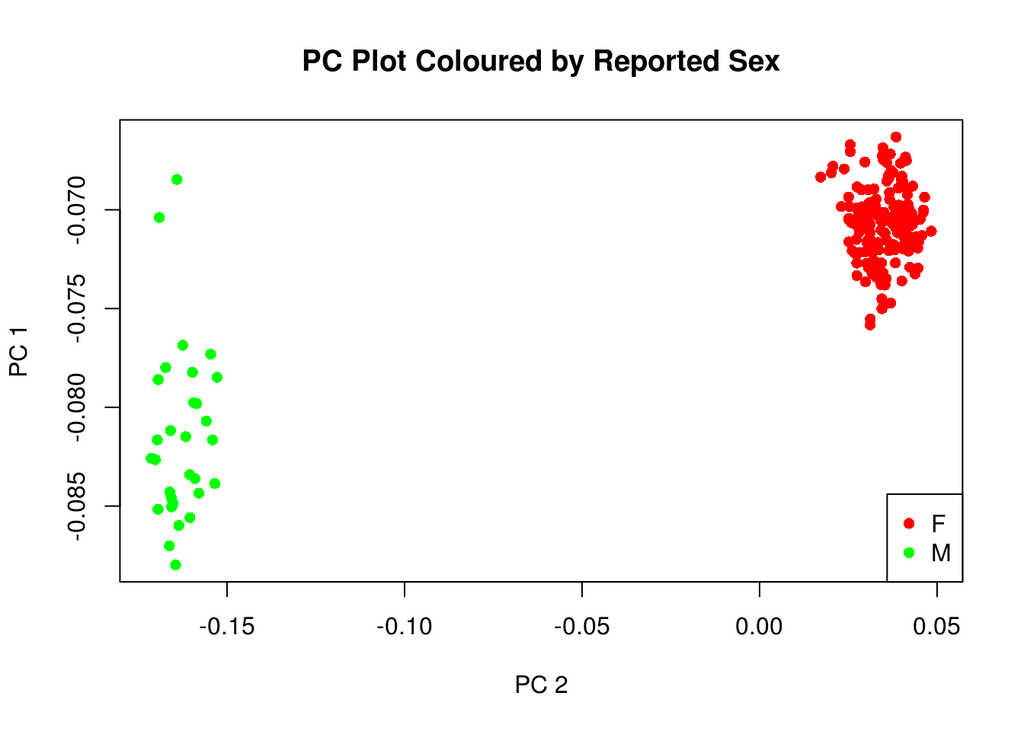

Here 0 number of sampless predicted sex does not match their reported sex. These samples fail the QC according to the findGenderPC function and, and will be removed.

```r
print(Stepsummary)
```

```
##                  Step1 Step2 Step3
## Failed This Step     2     0     0
## Total Failed         2     2     2
```

# 5 Methylation Distribution

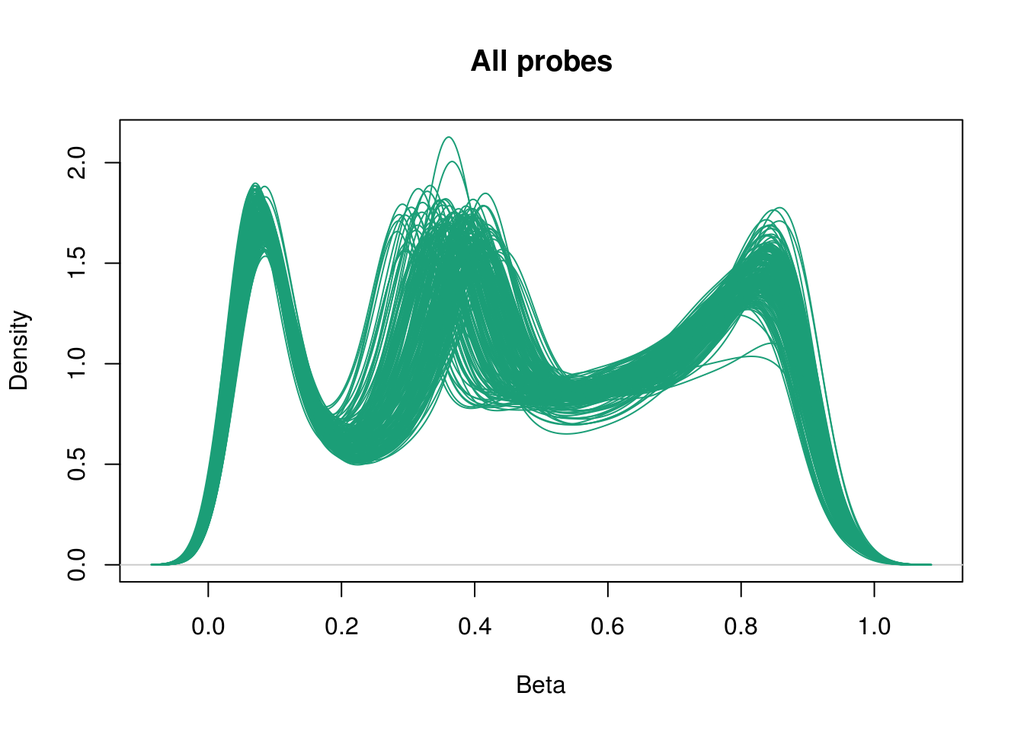

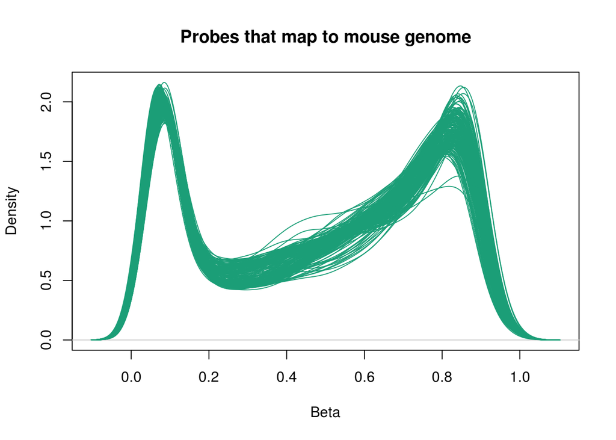